# Section 4.5 Python Example

```python
import numpy as np
import pandas as pd
import matplotlib.pyplot as plt
import statsmodels.api as sm
from patsy import dmatrix
from pygam import LinearGAM, s

pd.set_option('display.precision', 3)
plt.rcParams['figure.figsize'] = (6, 4)
```

## Birthrate Example

The `Birthrate` data set contains annual U.S. birth rates from 1917 to 2003.

```python
birthrates = pd.read_csv("birthrates.csv")
print(birthrates.head())
```

```
   Year  Birthrate
0  1917      183.1
1  1918      183.9
2  1919      163.1
3  1920      179.5
4  1921      181.4
```

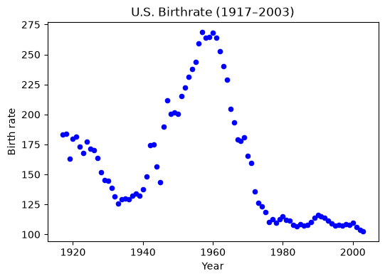

```python
plt.scatter(birthrates['Year'], birthrates['Birthrate'], color="blue", s=20)
plt.xlabel('Year')
plt.ylabel('Birth rate')
plt.title('U.S. Birthrate (1917–2003)')
plt.show()
```

The series exhibits a highly nonlinear trend. We first fit orthogonal polynomial regressions of degrees 3 and 6.

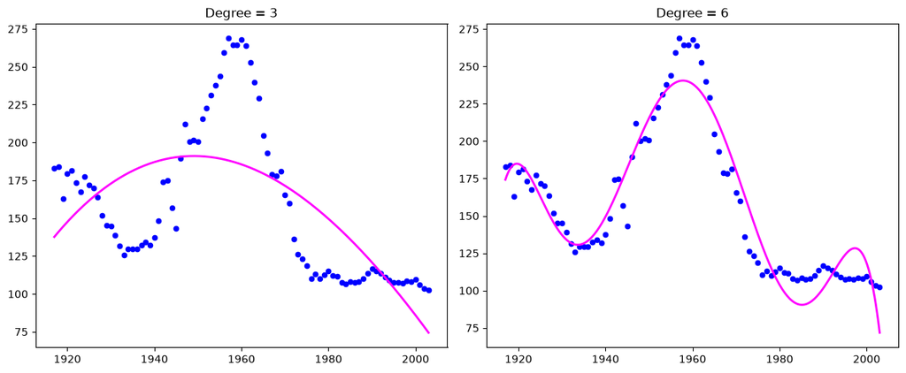

```python
X = birthrates["Year"]
y = birthrates["Birthrate"]

def fit_orthopoly(x, y, degree):
    # Scale to [-1, 1] and use Legendre polynomials (orthogonal on that interval)
    X_poly = np.polynomial.legendre.legvander(
        np.interp(x, (x.min(), x.max()), (-1, 1)), degree
    )
    model = sm.OLS(y, X_poly).fit()

    x_grid = np.linspace(x.min(), x.max(), 300)
    x_scaled = np.interp(x_grid, (x.min(), x.max()), (-1, 1))
    X_grid_poly = np.polynomial.legendre.legvander(x_scaled, degree)
    y_pred = model.predict(X_grid_poly)
    return x_grid, y_pred

x3, y3 = fit_orthopoly(X, y, 3)
x6, y6 = fit_orthopoly(X, y, 6)

fig, axes = plt.subplots(1, 2, figsize=(12, 5))

axes[0].scatter(X, y, color="blue", s=20)
axes[0].plot(x3, y3, color="magenta", linewidth=2)
axes[0].set_title("Degree = 3")

axes[1].scatter(X, y, color="blue", s=20)
axes[1].plot(x6, y6, color="magenta", linewidth=2)
axes[1].set_title("Degree = 6")

plt.tight_layout()
plt.show()
```

The degree-6 polynomial improves on the cubic fit but still fails to capture the sharp changes in the series. We next try simple piecewise polynomials (constant and linear) with three interior knots.

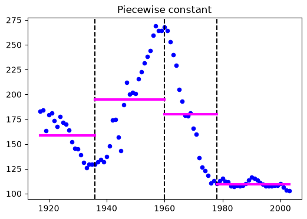

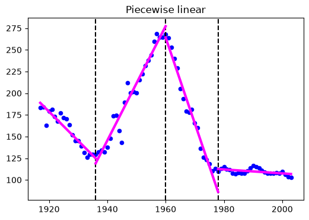

```python
years = birthrates["Year"].values
rates = birthrates["Birthrate"].values

myknots = [1936, 1960, 1978]
bounds = [1917] + myknots + [2003]

# ---------- Piecewise constant ----------
X_const = np.column_stack([
    (years < myknots[0]),
    (years >= myknots[0]) & (years < myknots[1]),
    (years >= myknots[1]) & (years < myknots[2]),
    (years >= myknots[2])
]).astype(float)

const_model = sm.OLS(rates, X_const).fit()

plt.figure()
plt.scatter(years, rates, color="blue", s=20)
for knot in myknots:
    plt.axvline(knot, linestyle="--", color="black")

for k in range(4):
    plt.plot(
        [bounds[k], bounds[k+1]],
        [const_model.params[k]] * 2,
        color="magenta", linewidth=3
    )
plt.title("Piecewise constant")
plt.show()

# ---------- Piecewise linear (discontinuous) ----------
X_linear = np.column_stack([
    (years < myknots[0]),
    (years >= myknots[0]) & (years < myknots[1]),
    (years >= myknots[1]) & (years < myknots[2]),
    (years >= myknots[2]),
    years * (years < myknots[0]),
    years * ((years >= myknots[0]) & (years < myknots[1])),
    years * ((years >= myknots[1]) & (years < myknots[2])),
    years * (years >= myknots[2])
]).astype(float)

line_model = sm.OLS(rates, X_linear).fit()

plt.figure()
plt.scatter(years, rates, color="blue", s=20)
for knot in myknots:
    plt.axvline(knot, linestyle="--", color="black")

for k in range(4):
    plt.plot(
        [bounds[k], bounds[k+1]],
        line_model.params[k] + np.array([bounds[k], bounds[k+1]]) * line_model.params[k+4],
        color="magenta", linewidth=3
    )
plt.title("Piecewise linear")
plt.show()
```

These piecewise fits are local, but the discontinuities at the knots produce an unsatisfactory overall curve.

### Regression Splines

A better approach is to use splines, which enforce continuity (and, for cubic splines, continuity of derivatives). We begin with a linear B-spline.

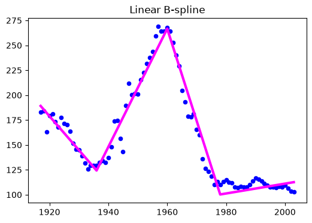

```python
X_bs = dmatrix("bs(year, knots=(1936,1960,1978), degree=1, include_intercept=True)",
               {"year": birthrates["Year"]}, return_type='dataframe')

model_bs = sm.OLS(birthrates["Birthrate"], X_bs).fit()

plt.figure()
plt.scatter(birthrates["Year"], birthrates["Birthrate"], color="blue", s=20)
plt.plot(birthrates["Year"], model_bs.fittedvalues, color="magenta", linewidth=3)
plt.title("Linear B-spline")
plt.show()
```

Next we fit a cubic B-spline with the same three knots.

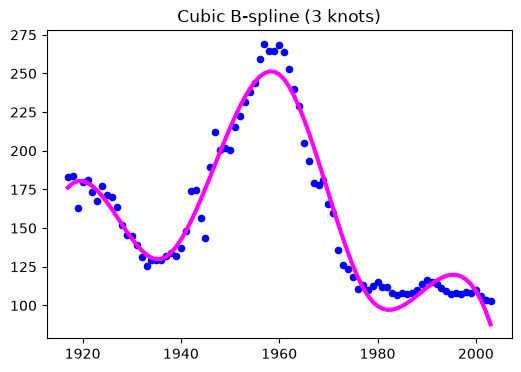

```python
X_bs3 = dmatrix("bs(year, knots=(1936,1960,1978), degree=3, include_intercept=True)",
                {"year": birthrates["Year"]}, return_type='dataframe')

model_bs3 = sm.OLS(birthrates["Birthrate"], X_bs3).fit()

plt.figure()
plt.scatter(birthrates["Year"], birthrates["Birthrate"], color="blue", s=20)
plt.plot(birthrates["Year"], model_bs3.fittedvalues, color="magenta", linewidth=3)
plt.title("Cubic B-spline (3 knots)")
plt.show()
```

Instead of specifying the knots directly we can request a target number of degrees of freedom; the basis constructor then places the knots at appropriate quantiles.

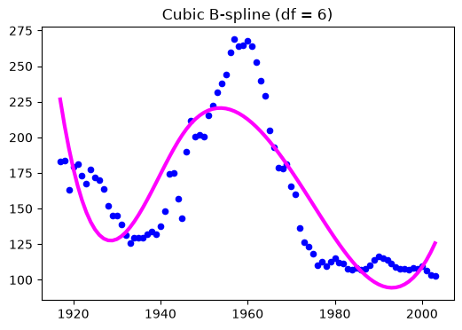

```python
X_bs_df = dmatrix("bs(year, df=6, degree=3, include_intercept=True)",
                  {"year": birthrates["Year"]}, return_type='dataframe')

model_bs_df = sm.OLS(birthrates["Birthrate"], X_bs_df).fit()

plt.figure()
plt.scatter(birthrates["Year"], birthrates["Birthrate"], color="blue", s=20)
plt.plot(birthrates["Year"], model_bs_df.fittedvalues, color="magenta", linewidth=3)
plt.title("Cubic B-spline (df = 6)")
plt.show()
```

Natural cubic splines impose the additional constraint that the function is linear beyond the boundary knots.

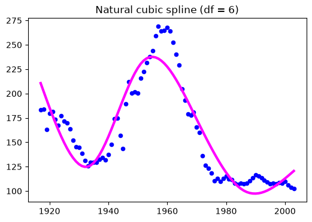

```python
X_ns = dmatrix("cr(year, df=6, lower_bound=1917, upper_bound=2003)",
               {"year": birthrates["Year"]}, return_type='dataframe')

model_ns = sm.OLS(birthrates["Birthrate"], X_ns).fit()

order = np.argsort(birthrates["Year"].values)

plt.figure()
plt.scatter(birthrates["Year"], birthrates["Birthrate"], color="blue", s=20)
plt.plot(birthrates["Year"].values[order],
         model_ns.fittedvalues.values[order],
         color="magenta", linewidth=3)
plt.title("Natural cubic spline (df = 6)")
plt.show()
```

**Note.** The natural-cubic-spline basis implemented by `patsy` is not identical to the one produced by R’s `ns()` function, so the fitted curves may differ slightly even when the nominal degrees of freedom are the same.

## A Simulated Example of Smoothing Splines

We now reproduce the classic illustration from Section 5.5.2 of *Elements of Statistical Learning*. The true regression function is

$$ f(x) = \frac{\sin\bigl(12(x+0.2)\bigr)}{x+0.2}, \qquad x \in [0,1]. $$

We generate noisy observations from this curve:

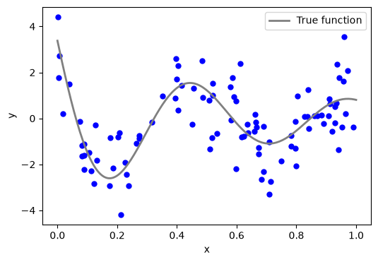

```python
np.random.seed(598)
n = 100

x = np.sort(np.random.uniform(0, 1, n))
y = np.sin(12 * (x + 0.2)) / (x + 0.2) + np.random.normal(0, 1, n)

xx = np.linspace(0, 1, 200)
yy = np.sin(12 * (xx + 0.2)) / (xx + 0.2)

plt.scatter(x, y, color="blue", s=25)
plt.plot(xx, yy, color="gray", linewidth=2, label="True function")
plt.xlabel("x")
plt.ylabel("y")
plt.legend()
plt.show()
```

### Fitting a Smoothing Spline

In Python we use the `LinearGAM` class from the `pygam` package (with a spline term). The argument `n_splines` plays a role analogous to the degrees of freedom in R’s `smooth.spline`.

```python
gam5 = LinearGAM(s(0, n_splines=5)).fit(x, y)
print(gam5.summary())
```

```
LinearGAM
=============================================== ==========================================================
Distribution:                        NormalDist Effective DoF:                                      2.7453
Link Function:                     IdentityLink Log Likelihood:                                  -185.5807
Number of Samples:                          100 AIC:                                               378.652
                                                AICc:                                             379.0252
                                                GCV:                                                2.5902
                                                Scale:                                              1.5692
                                                Pseudo R-Squared:                                   0.0429
==========================================================================================================
Feature Function                  Lambda               Rank         EDoF         P > x        Sig. Code
================================= ==================== ============ ============ ============ ============
s(0)                              [0.6]                5            2.7          9.72e-08     ***
intercept                                              1            0.0          5.27e-01
==========================================================================================================
Significance codes:  0 '***' 0.001 '**' 0.01 '*' 0.05 '.' 0.1 ' ' 1

WARNING: Fitting splines and a linear function to a feature introduces a model identifiability problem
         which can cause p-values to appear significant when they are not.

WARNING: p-values calculated in this manner behave correctly for un-penalized models or models with
         known smoothing parameters, but when smoothing parameters have been estimated, the p-values
         are typically lower than they should be, meaning that the tests reject the null too readily.
None
```

We plot the fitted curve together with the true function:

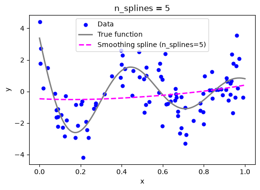

```python
fitted5 = gam5.predict(xx)

plt.scatter(x, y, color="blue", s=25, label="Data")
plt.plot(xx, yy, color="gray", linewidth=2, label="True function")
plt.plot(xx, fitted5, color="magenta", linestyle="--", linewidth=2,
         label="Smoothing spline (n_splines=5)")
plt.xlabel("x")
plt.ylabel("y")
plt.title("n_splines = 5")
plt.legend()
plt.show()
```

Increasing the number of splines produces a more flexible fit:

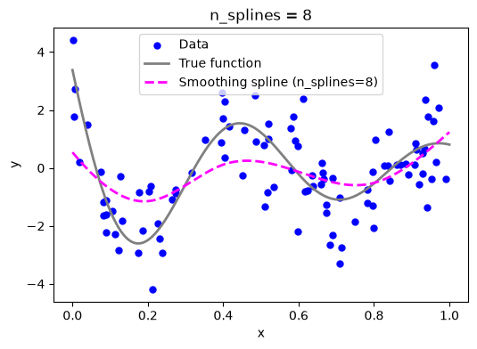

```python
gam8 = LinearGAM(s(0, n_splines=8)).fit(x, y)
fitted8 = gam8.predict(xx)

plt.scatter(x, y, color="blue", s=25, label="Data")
plt.plot(xx, yy, color="gray", linewidth=2, label="True function")
plt.plot(xx, fitted8, color="magenta", linestyle="--", linewidth=2,
         label="Smoothing spline (n_splines=8)")
plt.xlabel("x")
plt.ylabel("y")
plt.title("n_splines = 8")
plt.legend()
plt.show()
```

### Choice of the Smoothing Parameter

In practice the smoothing parameter (or equivalently the effective degrees of freedom) is chosen by cross-validation. The `pygam` package provides several built-in criteria. Here we examine the effective degrees of freedom and the leverages (diagonal entries of the smoother matrix).

```python
gam9 = LinearGAM(s(0, n_splines=9)).fit(x, y)
print(gam9.summary())
```

```
LinearGAM
=============================================== ==========================================================
Distribution:                        NormalDist Effective DoF:                                      4.9457
Link Function:                     IdentityLink Log Likelihood:                                  -159.9178
Number of Samples:                          100 AIC:                                              331.7269
                                                AICc:                                             332.6145
                                                GCV:                                                1.6532
                                                Scale:                                              1.2275
                                                Pseudo R-Squared:                                   0.4276
==========================================================================================================
Feature Function                  Lambda               Rank         EDoF         P > x        Sig. Code
================================= ==================== ============ ============ ============ ============
s(0)                              [0.6]                9            4.9          0.00e+00     ***
intercept                                              1            0.0          8.72e-05     ***
==========================================================================================================
Significance codes:  0 '***' 0.001 '**' 0.01 '*' 0.05 '.' 0.1 ' ' 1

WARNING: Fitting splines and a linear function to a feature introduces a model identifiability problem
         which can cause p-values to appear significant when they are not.

WARNING: p-values calculated in this manner behave correctly for un-penalized models or models with
         known smoothing parameters, but when smoothing parameters have been estimated, the p-values
         are typically lower than they should be, meaning that the tests reject the null too readily.
None
```

```python
# Construct the smoother matrix and extract leverages
X_basis = gam9._modelmat(x.reshape(-1, 1))
Xmat = X_basis.toarray()

XtX_inv = np.linalg.pinv(Xmat.T @ Xmat)
H = Xmat @ XtX_inv @ Xmat.T
leverages = np.diag(H)

print("First 10 leverages:", np.round(leverages[:10], 4))
print("Sum of leverages:", leverages.sum())
print("Effective df reported by pygam:", gam9.statistics_['edof'])
```

```
First 10 leverages: [0.2974 0.2742 0.2533 0.1547 0.1192 0.1161 0.1103 0.1096 0.1029 0.1026]
Sum of leverages: 8.999999999999932
Effective df reported by pygam: 4.945695733987347
```

We can also compute the generalized cross-validation (GCV) and leave-one-out cross-validation (LOOCV) scores manually:

```python
y_hat = gam9.predict(x)

rss = np.sum((y - y_hat)**2)
edof = gam9.statistics_['edof']

gcv = rss / ((1 - edof / n)**2) / n
print("GCV:", gcv)

loocv = np.mean(((y - y_hat) / (1 - leverages))**2)
print("LOOCV:", loocv)
```

```
GCV: 1.5851151455014354
LOOCV: 1.919695670296906
```

Both criteria can be examined over a grid of `n_splines` (or smoothing-parameter values) to select a final model.